# Reproducible Research. Course project1

Nadine.solov

04 12 2021

This assignment makes use of data from a personal activity monitoring device. This device collects data at 5 minute intervals through out the day. The data consists of two months of data from an anonymous individual collected during the months of October and November, 2012 and include the number of steps taken in 5 minute intervals each day.

The data downloaded to the computer, unzipped. Read data into object variable dataFile

```r
dataFile <- read.csv("./data/activity.csv")
```

Observe data using summary()

```r
summary(dataFile)
```

```
##      steps            date              interval
##  Min.   :  0.00   Length:17568       Min.   :   0.0
##  1st Qu.:  0.00   Class :character   1st Qu.: 588.8
##  Median :  0.00   Mode  :character   Median :1177.5
##  Mean   : 37.38                      Mean   :1177.5
##  3rd Qu.: 12.00                      3rd Qu.:1766.2
##  Max.   :806.00                      Max.   :2355.0
##  NA's   :2304
```

```r
str(dataFile)
```

```
## 'data.frame':    17568 obs. of  3 variables:
##  $ steps   : int  NA NA NA NA NA NA NA NA NA NA ...
##  $ date    : chr  "2012-10-01" "2012-10-01" "2012-10-01" "2012-10-01" ...
##  $ interval: int  0 5 10 15 20 25 30 35 40 45 ...
```

Observe data again

```r
str(dataFile)
```

```
## 'data.frame':    17568 obs. of  3 variables:
##  $ steps   : int  NA NA NA NA NA NA NA NA NA NA ...
##  $ date    : chr  "2012-10-01" "2012-10-01" "2012-10-01" "2012-10-01" ...
##  $ interval: int  0 5 10 15 20 25 30 35 40 45 ...
```

```r
steps_by_day <- aggregate(steps ~ date, data=dataFile, sum)
```

histogram of the total number of steps taken each day

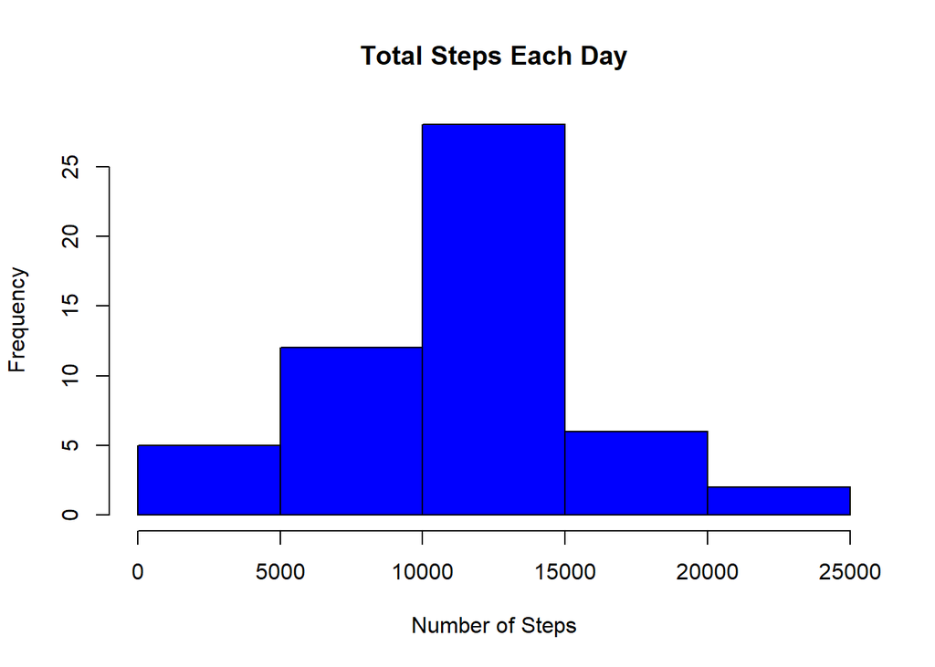

```r
hist(steps_by_day$steps, main = paste("Total Steps Each Day"), col="blue",
     xlab="Number of Steps")
```

mean and median number of steps taken each day

```r
rmean <- mean(steps_by_day$steps)
rmean
```

```
## [1] 10766.19
```

```r
rmedian <- median(steps_by_day$steps)
rmedian
```

```
## [1] 10765
```

Time series plot of the average number of steps taken

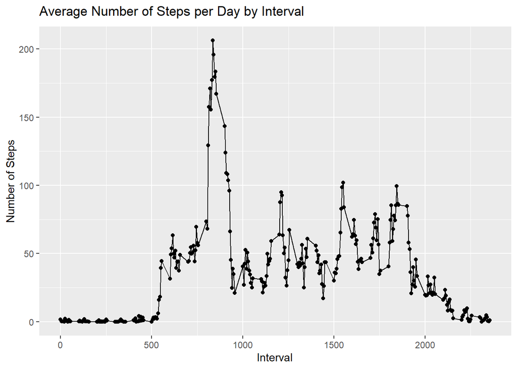

```r
aver_numb_steps<-aggregate(steps ~ interval, data=dataFile, mean)

library(ggplot2)
ggplot(aver_numb_steps, aes(interval,steps))+
  geom_line() +
  geom_point() +
  ggtitle(expression("Average Number of Steps per Day by Interval"))+
  labs(x = "Interval", y ="Number of Steps")
```

The 5-minute interval that, on average, contains the maximum number of steps is 835:

```r
max_interval <- aver_numb_steps[which.max(aver_numb_steps$steps),1]
max_interval
```

```
## [1] 835
```

a set of missing values using the mice package and the md.pattern function

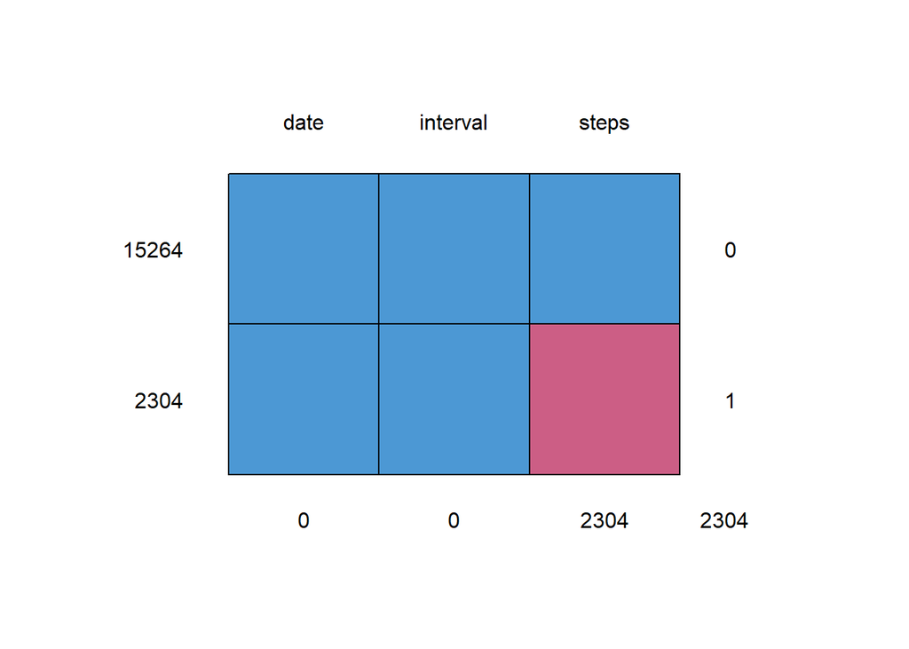

```
##       date interval steps
## 15264    1        1     1    0
## 2304     1        1     0    1
##          0        0  2304 2304
```

```r
library(mice)
md.pattern(dataFile)
```

2304 values belong to a variable steps

```r
sum(is.na(dataFile$steps))
```

```
## [1] 2304
```

Create a new dataset that is equal to the original dataset

```r
impute.dataFile <- dataFile
```

filling in missing values in the dataset use the mean

```r
impute.dataFile$steps[is.na(impute.dataFile$steps)] <- mean(impute.dataFile$steps,na.rm=TRUE)
impute.dataFile$steps <- as.numeric(impute.dataFile$steps)
impute.dataFile$interval <- as.numeric(impute.dataFile$interval)
colSums(is.na(impute.dataFile))
```

```
##    steps     date interval
##        0        0        0
```

Create a new dataset that is equal to the original dataset but with the missing data filled in

```r
summary(impute.dataFile)
```

```
##      steps            date              interval
##  Min.   :  0.00   Length:17568       Min.   :   0.0
##  1st Qu.:  0.00   Class :character   1st Qu.: 588.8
##  Median :  0.00   Mode  :character   Median :1177.5
##  Mean   : 37.38                      Mean   :1177.5
##  3rd Qu.: 37.38                      3rd Qu.:1766.2
##  Max.   :806.00                      Max.   :2355.0
```

Make a histogram of the total number of steps taken each day

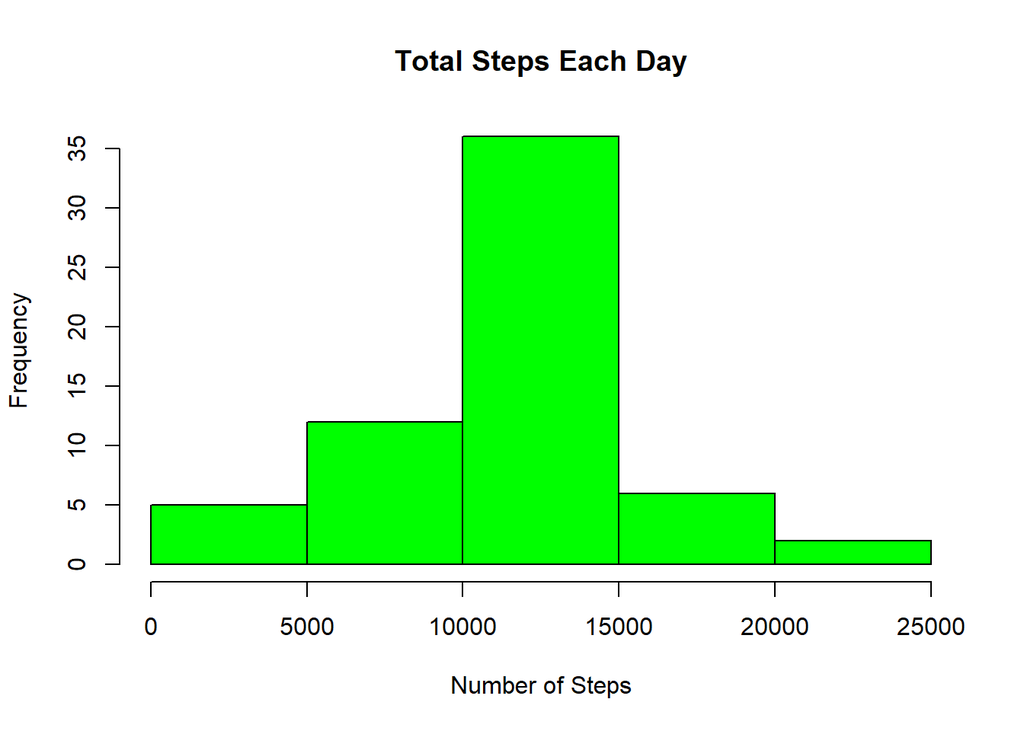

```r
steps_by_day_i <- aggregate(steps ~ date, impute.dataFile, sum)
hist(steps_by_day_i$steps, main = paste("Total Steps Each Day"), col="Green",
     xlab="Number of Steps")
```

Calculate and report the mean and median total number of steps taken per day

```r
rmean.i <-  mean(steps_by_day_i$steps)
rmean.i
```

```
## [1] 10766.19
```

```r
rmedian.i <- median(steps_by_day_i$steps)
rmedian.i
```

```
## [1] 10766.19
```

Calculate difference between imputed and non-imputed data

```r
mean_diff <- rmean.i - rmean
print(mean_diff)
```

```
## [1] 0
```

```r
med_diff <- rmedian.i - rmedian
print(med_diff)
```

```
## [1] 1.188679
```

Total difference

```r
total_diff <- sum(steps_by_day_i$steps) - sum(steps_by_day$steps)
total_diff
```

```
## [1] 86129.51
```

Create a new factor variable in the dataset with two levels – “weekday” and “weekend” indicating whether a given date is a weekday or weekend day.

```r
library(chron)
table(is.weekend(impute.dataFile$date))
```

```
##
## FALSE  TRUE
## 12960  4608
```

Adding new factor variable “dayofweek” indicating whether a given date is a weekday or weekend day

```r
impute.dataFile$dayofweek <- ifelse(is.weekend(impute.dataFile$date), "weekend",
                          "weekday")
table(impute.dataFile$dayofweek)
```

```
##
## weekday weekend
##   12960    4608
```

```r
head(impute.dataFile)
```

```
##     steps       date interval dayofweek
## 1 37.3826 2012-10-01        0   weekday
## 2 37.3826 2012-10-01        5   weekday
## 3 37.3826 2012-10-01       10   weekday
## 4 37.3826 2012-10-01       15   weekday
## 5 37.3826 2012-10-01       20   weekday
## 6 37.3826 2012-10-01       25   weekday
```

```r
meanintervalnew<- aggregate(steps ~ interval + dayofweek, impute.dataFile, FUN=mean)
```

Aggregated Data

```r
head(meanintervalnew)
```

```
##   interval dayofweek    steps
## 1        0   weekday 7.006569
## 2        5   weekday 5.384347
## 3       10   weekday 5.139902
## 4       15   weekday 5.162124
## 5       20   weekday 5.073235
## 6       25   weekday 6.295458
```

Time Series plot using ggplot

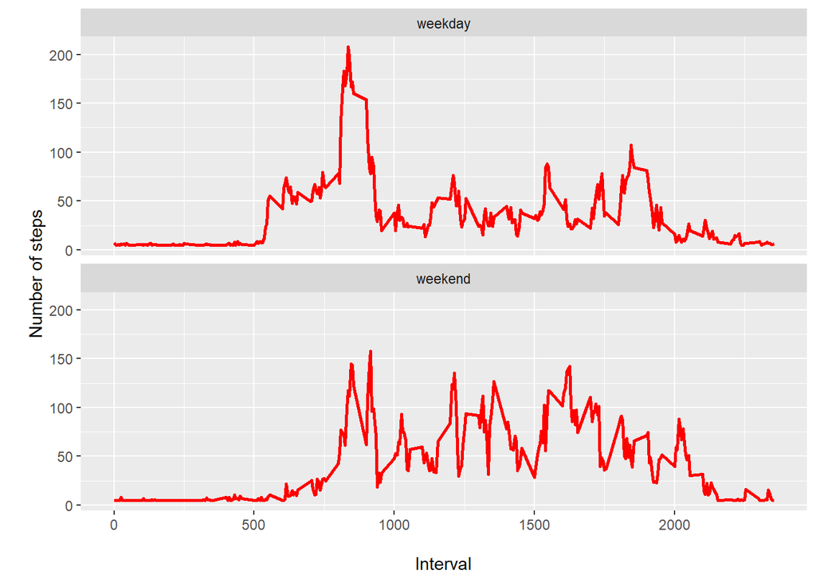

```r
ggplot(meanintervalnew, aes(x=interval, y=steps)) +
  geom_line(color="red", size=1) +
  facet_wrap(~dayofweek, nrow=2) +
  labs(x="\nInterval", y="\nNumber of steps")
```